# Week 4 Assignment Data Visualization

## MSCA 37014 Python for Analytics

### Week 4 Assignment Data Visualization (100 Points)

### Due Date: 9pm, Friday, 2/11/2022

Please submit your assignment solutions in **PDF** or **HTML** file; **Submitted Jupyter Notebook will not be graded**

### Part 1 - Matplotlib (Question 1-8)

### Part 2 - Seaborn (Question 9-16)

## Part 1 - Matplotlib

### Questions 1. Import matplotlib.pyplot as plt and set %matplotlib inline if you are using the jupyter notebook. What command do you use if you aren't using the jupyter notebook? (5 points)

```python
# Type Your Answer Here:
import matplotlib.pyplot as plt
%matplotlib inline
```

### Follow the instructions to recreate the plots using this data for the Question 2 to 8 :

```python
import numpy as np
import matplotlib.pyplot as plt
%matplotlib inline
x = np.arange(0,50)
y = x*2
z = x**2
```

### Question 2. Follow along with these steps: (10 points)

- 1) Recreate a figure object called fig using plt.figure()
- 2) Use add_axes to add an axis to the figure canvas at [0,0,1,1]. Call this new axis ax.
- 3) Plot (x,y) on that axes and set the labels and titles to match the plot below:

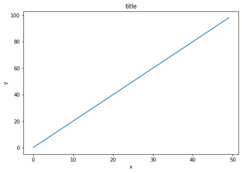

```python
# Type Your Answer Here:
fig = plt.figure()
ax = fig.add_axes([0,0,1,1])
ax.plot(x,y)
ax.set_xlabel('x')
ax.set_ylabel('y')
ax.set_title('title')
```

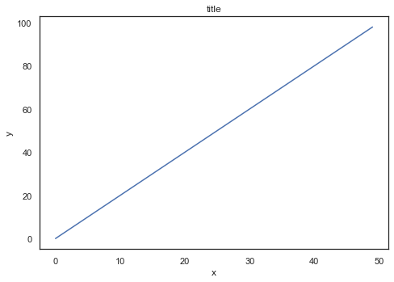

```python
# Output:
```

### Question 3. Create a figure object and put two axes on it, axes1 and axes2. Located at [0,0,1,1] and [0.2,0.5,.2,.2] respectively. (5 points)

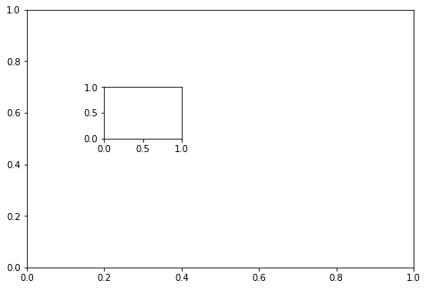

```python
# Type Your Answer Here:
fig = plt.figure()

ax1 = fig.add_axes([0,0,1,1])
ax2 = fig.add_axes([0.2,0.5,.2,.2])
```

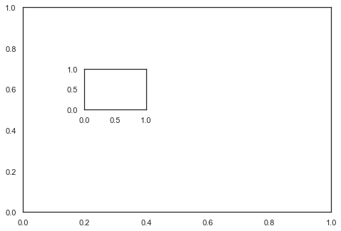

```python
# Output:
```

### Question 4. Now plot (x,y) on both axes. And call your figure object to show it. (10 points)

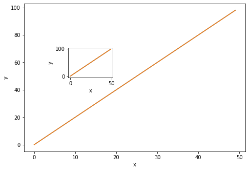

```python
# Type Your Answer Here:
ax1.plot(x,y)
ax1.set_xlabel('x')
ax1.set_ylabel('y')


ax2.plot(x,y)
ax2.set_xlabel('x')
ax2.set_ylabel('y')


fig
```

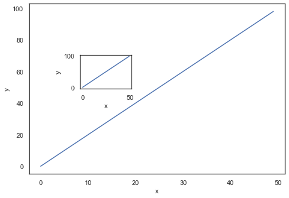

```python
# Output:
```

### Question 5. Create the plot below by adding two axes to a figure object at [0,0,1,1] and [0.2,0.5,.4,.4] (5 points)

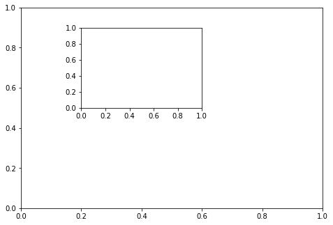

```python
# Type Your Answer Here:

fig = plt.figure()

ax = fig.add_axes([0,0,1,1])
ax2 = fig.add_axes([0.2,0.5,.4,.4])
```

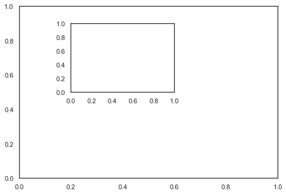

```python
# Output:
```

### Question 6. Use plt.subplots(nrows=1, ncols=2) to recreate the plot below. (5 points)

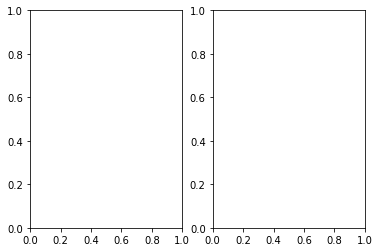

```python
# Type Your Answer Here:

fig, axes = plt.subplots(nrows=1, ncols=2)
```

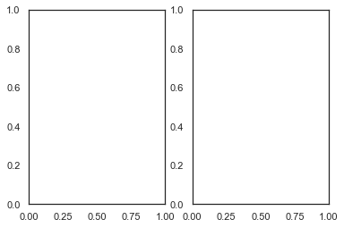

```python
# Output:
```

### Question 7. Now plot (x,y) and (x,z) on the axes. Play around with the linewidth and style. (5 points)

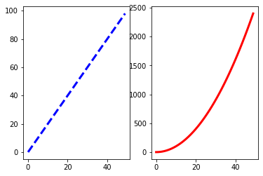

```python
# Type Your Answer Here:
axes[0].plot(x,y,color="blue", lw=3, ls='--')
axes[1].plot(x,z,color="red", lw=3, ls='-')
fig
```

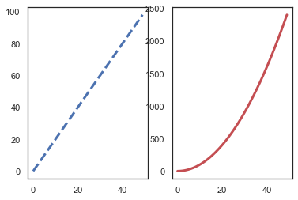

```python
# Output:
```

### Question 8. Resize the plot by adding the figsize() argument in plt.subplots() which is copying and pasting your previous code. (10 points)

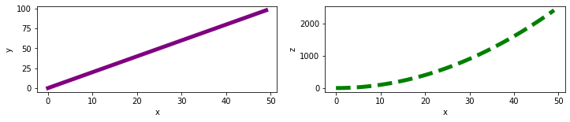

```python
# Type Your Answer Here:

fig, axes = plt.subplots(nrows=1, ncols=2,figsize=(12,2))

axes[0].plot(x,y,color="purple", lw=5)
axes[0].set_xlabel('x')
axes[0].set_ylabel('y')

axes[1].plot(x,z,color="green", lw=5, ls='--')
axes[1].set_xlabel('x')
axes[1].set_ylabel('z')
```

[figure not shown]

```python
# Output:
```

## Part 2 - Seaborn

Recreate the plots below (don't worry about color schemes, just the plot itself.

### Use the famous titanic data set for the Question 9 to 14:

```python
import seaborn as sbn
import matplotlib.pyplot as plt
%matplotlib inline
sbn.set_style('white')
```

```python
titanic = sbn.load_dataset('titanic')
```

```python
titanic.head()
```

|  | survived | pclass | sex | age | sibsp | parch | fare | embarked | class | who | adult_male | deck | embark_town | alive | alone |
| --- | --- | --- | --- | --- | --- | --- | --- | --- | --- | --- | --- | --- | --- | --- | --- |
| 0 | 0 | 3 | male | 22.0 | 1 | 0 | 7.2500 | S | Third | man | True | NaN | Southampton | no | False |
| 1 | 1 | 1 | female | 38.0 | 1 | 0 | 71.2833 | C | First | woman | False | C | Cherbourg | yes | False |
| 2 | 1 | 3 | female | 26.0 | 0 | 0 | 7.9250 | S | Third | woman | False | NaN | Southampton | yes | True |
| 3 | 1 | 1 | female | 35.0 | 1 | 0 | 53.1000 | S | First | woman | False | C | Southampton | yes | False |
| 4 | 0 | 3 | male | 35.0 | 0 | 0 | 8.0500 | S | Third | man | True | NaN | Southampton | no | True |

```python
titanic.columns
```

```
Index(['survived', 'pclass', 'sex', 'age', 'sibsp', 'parch', 'fare',
       'embarked', 'class', 'who', 'adult_male', 'deck', 'embark_town',
       'alive', 'alone'],
      dtype='object')
```

### Question 9. Plot both the `fare` and `age` columns in one chart. (5 points)

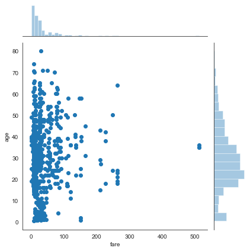

```python
# Type Your Answer Here:


sbn.jointplot(x='fare',y='age',data=titanic,kind='scatter')
```

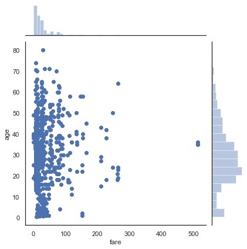

```python
# Output:
```

### Question 10. Create a distplot based on the `fare` column. (5 points)

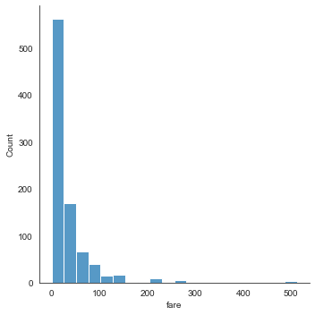

```python
# Type Your Answer Here:
import seaborn as sbn
sbn.displot(titanic['fare'],kde=False,bins=20)
```

[figure not shown]

```python
# Output:
```

### Question 11. Create a boxplot based on the `class` and `age` columns using rainbow palette. (5 points)

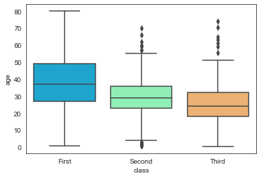

```python
# Type Your Answer Here:
sbn.boxplot(x="class", y="age", data=titanic,palette='rainbow')
```

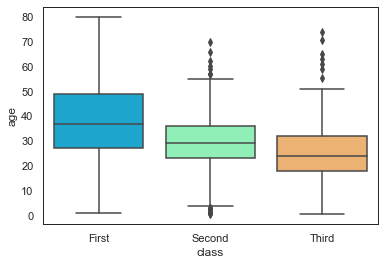

```python
# Output:
```

### Question 12. Create a countplot based on the `sex`column. (5 points)

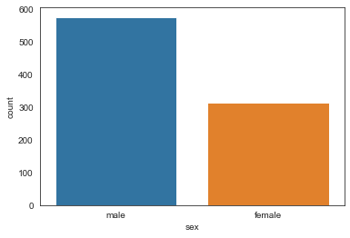

```python
# Type Your Answer Here:
sbn.countplot(x='sex',data=titanic)
```

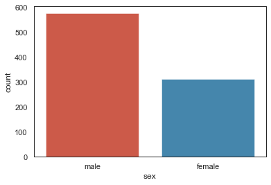

```python
# Output:
```

### Question 13. Create a correlation table and then use it to plot a clustermap. (5 points)

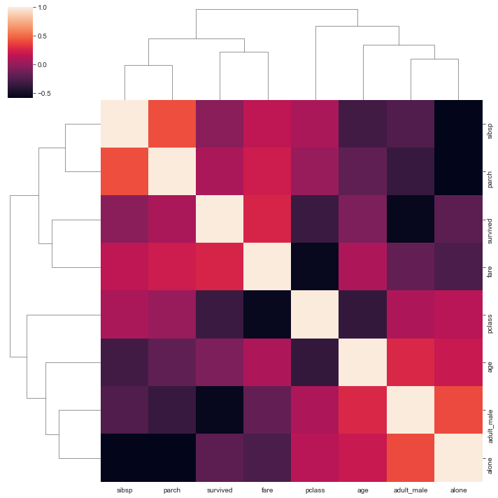

```python
# Type Your Answer Here:

sbn.clustermap(titanic.corr())
```

[figure not shown]

```python
# Output:
```

### Question 14. Use FacetGrid to create two histograms separated by the `sex` column. (5 points)

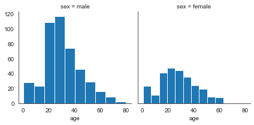

```python
# Type Your Answer Here:
g = sbn.FacetGrid(titanic, col="sex")
g = g.map(plt.hist,"age").add_legend
```

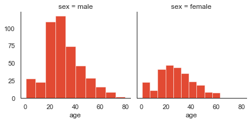

```python
# Output:
```

### Use the famous iris data set for 15-16 questions:

### Question 15. Use the iris built-in dataset to plot pairwise relationships across an entire dataframe for the numerical columns and use one categorical column as the color hue argument. (5 points)

```python
iris = sbn.load_dataset('iris')
iris.head(5)
```

|  | sepal_length | sepal_width | petal_length | petal_width | species |
| --- | --- | --- | --- | --- | --- |
| 0 | 5.1 | 3.5 | 1.4 | 0.2 | setosa |
| 1 | 4.9 | 3.0 | 1.4 | 0.2 | setosa |
| 2 | 4.7 | 3.2 | 1.3 | 0.2 | setosa |
| 3 | 4.6 | 3.1 | 1.5 | 0.2 | setosa |
| 4 | 5.0 | 3.6 | 1.4 | 0.2 | setosa |

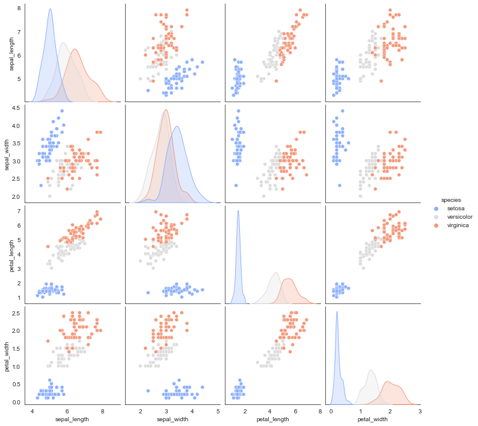

```python
# Type Your Answer Here:
sbn.pairplot(iris, hue='species', palette='coolwarm')
```

[figure not shown]

```python
# Output:
```

### Question 16. Use the Iris dataset to create a correlation table; then create a heatmap based on the correlation table. (10 points)

```python
# Type Your Answer Here:
iris.corr()
```

|  | sepal_length | sepal_width | petal_length | petal_width |
| --- | --- | --- | --- | --- |
| sepal_length | 1.000000 | -0.117570 | 0.871754 | 0.817941 |
| sepal_width | -0.117570 | 1.000000 | -0.428440 | -0.366126 |
| petal_length | 0.871754 | -0.428440 | 1.000000 | 0.962865 |
| petal_width | 0.817941 | -0.366126 | 0.962865 | 1.000000 |

```python
# Output:
```

|  | sepal_length | sepal_width | petal_length | petal_width |
| --- | --- | --- | --- | --- |
| sepal_length | 1.000000 | -0.117570 | 0.871754 | 0.817941 |
| sepal_width | -0.117570 | 1.000000 | -0.428440 | -0.366126 |
| petal_length | 0.871754 | -0.428440 | 1.000000 | 0.962865 |
| petal_width | 0.817941 | -0.366126 | 0.962865 | 1.000000 |

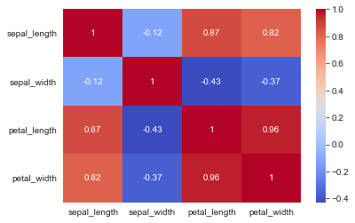

```python
# Type Your Answer Here:
sbn.heatmap(iris.corr(),cmap='coolwarm',annot=True)
```

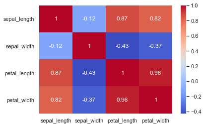

```python
# Output:
```